# Midterm Project- R Code and Outputs

## Load in neccessary packages

```r
library(tidymodels)
library(caret)
library(corrplot)
library(glmnet)
library(kableExtra)
library(earth)
library(dplyr)
```

# Part I

Using this dataset, please help Researcher A build a prediction model for PFS, aiming to understand how demographic, tumor, and treatment characteristics influence progression-free survival in breast cancer patients.

To answer this question, your report should at least include the following:

Model Training: Provide a detailed description of the model training procedure and how you obtained the model. Your description should include sufficient detail so that another statistician can reproduce the same model. Points will be deducted if the details provided are insufficient to reproduce your results.

## Import and partition data using ‘tidymodels’ package

```r
load("data/datA.RData")
datA <- datA |>
  mutate(
    menopause = as.factor(menopause),
    race = as.factor(race),
    tumor_grade = as.factor(tumor_grade),
    ER = as.factor(ER),
    PR = as.factor(PR),
    HER2 = as.factor(HER2),
    stage = as.factor(stage),
    surgery = as.factor(surgery),
    chemo = as.factor(chemo),
    hormonal_therapy = as.factor(hormonal_therapy)
  )

set.seed(2)

datA_split = initial_split(datA, prop = 0.8)

# Extract the training and test data
training_datA = training(datA_split)
testing_datA = testing(datA_split)

# Training data
x_trainA = model.matrix(log_PFS ~ . - id, training_datA)[, -1]
y_trainA = training_datA$log_PFS

# Test data
x_testA = model.matrix(log_PFS ~ . - id, testing_datA)[, -1]
y_testA = testing_datA$log_PFS

# Remove ID
training_datA <- training_datA |>  select(-"id")
testing_datA  <- testing_datA  |> select(-"id")
```

## Exploratory Data Analysis

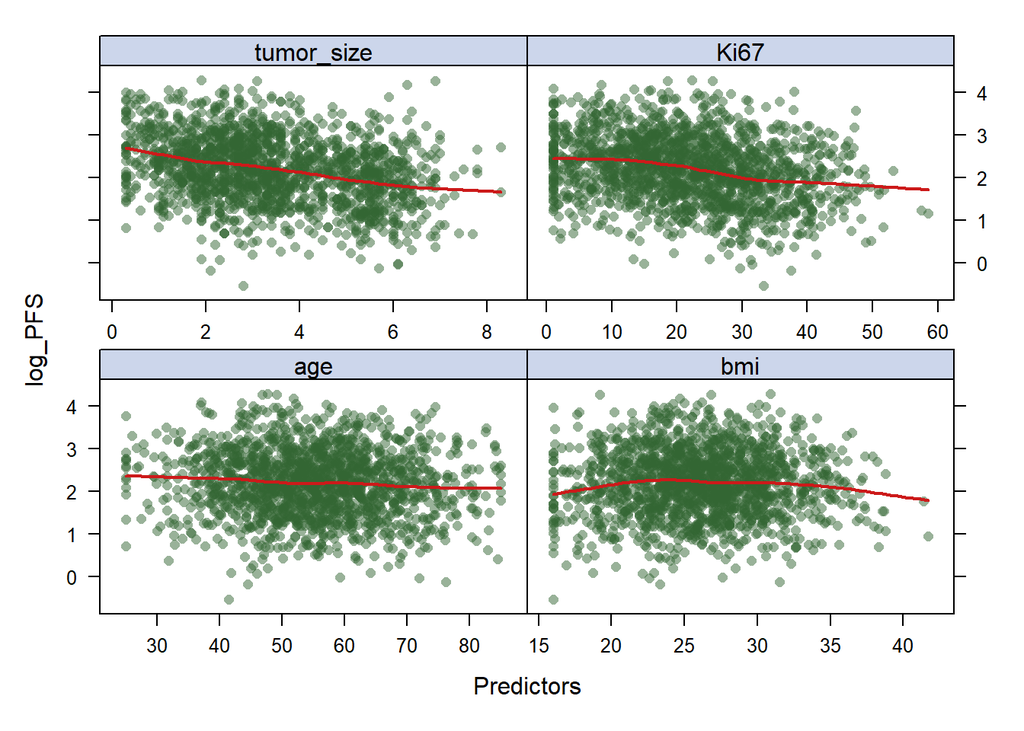

```r
# Changing the plot display
theme1 <- trellis.par.get()
theme1$plot.symbol$col <- rgb(.2, .4, .2, .5)
theme1$plot.symbol$pch <- 16
theme1$plot.line$col <- rgb(.8, .1, .1, 1)
theme1$plot.line$lwd <- 2
theme1$strip.background$col <- rgb(.0, .2, .6, .2)
trellis.par.set(theme1)

# Feature plots to look at trends between predictors and the outcome (log_PFS)
featurePlot(x = training_datA[ ,c(1, 4, 5, 11)],
            y = training_datA[ ,16],
            plot = "scatter",
            span = .5,
            labels = c("Predictors","log_PFS"),
            type = c("p", "smooth"),
            layout = c(2, 2))
```

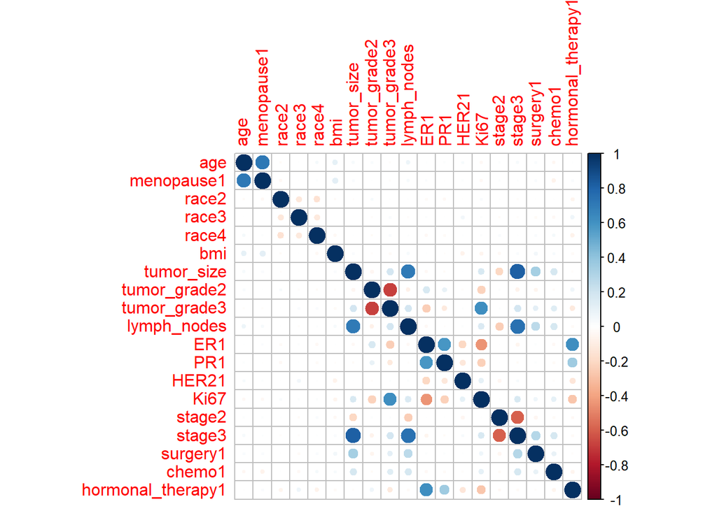

```r
# Calculates the correlation matrix for all the predictors
corrplot(cor(x_trainA), method = "circle", type = "full")
```

```r
# Elastic Net

set.seed(2)
ctrl1 <- trainControl(method = "cv", number = 10) # set up cv
set.seed(2) # set seed for reproduction

enet.fit <- train(log_PFS ~ .,
                  data = training_datA,
                  method = "glmnet",
                  tuneGrid = expand.grid(alpha = seq(0, 1, length = 21),
                                         lambda = exp(seq(-1, -7, length = 100))),
                  trControl = ctrl1)
enet.fit$bestTune
```

```
##      alpha     lambda
## 2047     1 0.01481491
```

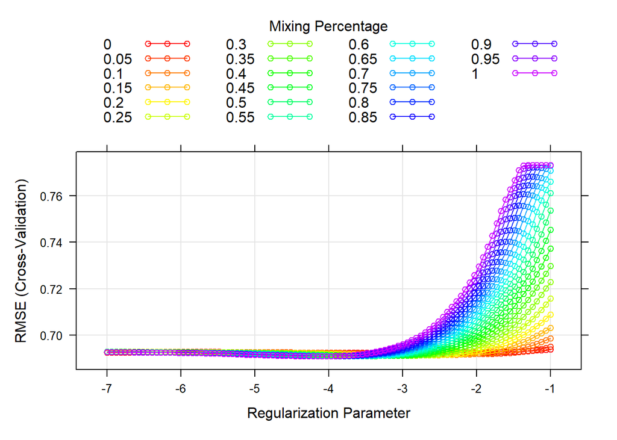

```r
myCol <- rainbow(25)
myPar <- list(superpose.symbol = list(col = myCol),
superpose.line = list(col = myCol))

plot(enet.fit, par.settings = myPar, xTrans = log)
```

```r
# Coefficients in the final model
coef(enet.fit$finalModel, enet.fit$bestTune$lambda)
```

```
## 20 x 1 sparse Matrix of class "dgCMatrix"
##                    s=0.01481491
## (Intercept)        2.6596549020
## age               -0.0025719864
## menopause1         .
## race2              .
## race3              0.0108623481
## race4             -0.0244504922
## bmi                .
## tumor_size        -0.0545380491
## tumor_grade2       .
## tumor_grade3      -0.1057179919
## lymph_nodes       -0.0540172355
## ER1                0.1709296973
## PR1                .
## HER21             -0.1732033529
## Ki67              -0.0046400332
## stage2             .
## stage3             .
## surgery1          -0.0009660964
## chemo1             .
## hormonal_therapy1  0.1589522549
```

Results: Report the model. Interpret the model and assess its performance.

```r
# Predict on testing_datA
enet.pred <- predict(enet.fit, newdata = testing_datA)

rmse_A <- RMSE(enet.pred, testing_datA$log_PFS)
r2_A  <- R2(enet.pred,   testing_datA$log_PFS)
```

```r
# Create table with the optimal tuning parameters for the chosen model
opt_para <- enet.fit$bestTune
rownames(opt_para) <- NULL
opt_para |>
  kable()
```

| alpha | lambda |
| --- | --- |
| 1 | 0.0148149 |

```r
# Create a table with the model coefficients
coefs1 <- as.data.frame(as.matrix(coef(enet.fit$finalModel, enet.fit$bestTune$lambda)))
coefs1$Predictors <- rownames(coefs1)
colnames(coefs1)[1] <- "Coefficients"
coefs1 <- coefs1[, c("Predictors", "Coefficients")]
rownames(coefs1) <- NULL
coefs1 |>
  kable()
```

| Predictors | Coefficients |
| --- | --- |
| (Intercept) | 2.6596549 |
| age | -0.0025720 |
| menopause1 | 0.0000000 |
| race2 | 0.0000000 |
| race3 | 0.0108623 |
| race4 | -0.0244505 |
| bmi | 0.0000000 |
| tumor_size | -0.0545380 |
| tumor_grade2 | 0.0000000 |
| tumor_grade3 | -0.1057180 |
| lymph_nodes | -0.0540172 |
| ER1 | 0.1709297 |
| PR1 | 0.0000000 |
| HER21 | -0.1732034 |
| Ki67 | -0.0046400 |
| stage2 | 0.0000000 |
| stage3 | 0.0000000 |
| surgery1 | -0.0009661 |
| chemo1 | 0.0000000 |
| hormonal_therapy1 | 0.1589523 |

```r
# Create a table with the exponentiated coefficients
coefs2 <- as.data.frame(as.matrix(coef(enet.fit$finalModel, enet.fit$bestTune$lambda)))
coefs2$Predictors <- rownames(coefs2)
colnames(coefs2)[1] <- "Exponentiated Coefficients"
coefs2 <- coefs2[, c("Predictors", "Exponentiated Coefficients")]
coefs2$`Exponentiated Coefficients`<- exp(coefs2$`Exponentiated Coefficients`)
rownames(coefs2) <- NULL
coefs2 |>
  kable()
```

| Predictors | Exponentiated Coefficients |
| --- | --- |
| (Intercept) | 14.2913563 |
| age | 0.9974313 |
| menopause1 | 1.0000000 |
| race2 | 1.0000000 |
| race3 | 1.0109216 |
| race4 | 0.9758460 |
| bmi | 1.0000000 |
| tumor_size | 0.9469225 |
| tumor_grade2 | 1.0000000 |
| tumor_grade3 | 0.8996783 |
| lymph_nodes | 0.9474158 |
| ER1 | 1.1864073 |
| PR1 | 1.0000000 |
| HER21 | 0.8409666 |
| Ki67 | 0.9953707 |
| stage2 | 1.0000000 |
| stage3 | 1.0000000 |
| surgery1 | 0.9990344 |
| chemo1 | 1.0000000 |
| hormonal_therapy1 | 1.1722820 |

```r
# Create table with model performance results
tibble(
  "RMSE" = rmse_A,
  "R^2" = r2_A
) |>
  kable()
```

| RMSE | R^2 |
| --- | --- |
| 0.7465867 | 0.1685384 |

# Part II

About a decade later, Researcher B conducted a separate study enrolling 2000 breast cancer patients diagnosed between 2000 and 2005, using the same study design and variable definitions. Like Researcher A’s study, all patients were followed until disease progression or death. Researcher B’s data are stored in datB.RData. Researcher A would like to evaluate whether the prediction model built on the original data generalizes well to Researcher B’s dataset. Does the model generalize well? If yes, provide justification. If not, build a new prediction model for the 2000–2005 cohort and discuss what has changed in prediction.

## Import dataset and create matrix

```r
load("data/datB.RData")

datB <- datB |>
  mutate(
    menopause = as.factor(menopause),
    race = as.factor(race),
    tumor_grade = as.factor(tumor_grade),
    ER = as.factor(ER),
    PR = as.factor(PR),
    HER2 = as.factor(HER2),
    stage = as.factor(stage),
    surgery = as.factor(surgery),
    chemo = as.factor(chemo),
    hormonal_therapy = as.factor(hormonal_therapy)
  )

# Remove id for matrix operations
all_datB <- datB |> select(-"id")
```

## Evaluate the model’s performance on researcher B’s dataset

```r
# Use all of datB to test generalizability of elastic net model
enet_pred_B <- predict(enet.fit, newdata = all_datB)

# Compare performances
rmse_B <- RMSE(enet_pred_B, all_datB$log_PFS)
r2_B <- R2(enet_pred_B, all_datB$log_PFS)


# Report table comparing performance
performance_table <- data.frame(
  Dataset = c("datA (Internal Test Set)", "datB (External Validation)"),
  RMSE = c(round(rmse_A, 4), round(rmse_B, 4)),
  r2 = c(round(r2_A, 4), round(r2_B, 4))
)

colnames(performance_table) <- c("Dataset", "RMSE", "R^2")

performance_table |>
  kable(caption = "Elastic Net Model Performance: Internal vs External Validation") |>
  kable_styling(full_width = FALSE)
```

Elastic Net Model Performance: Internal vs External Validation

| Dataset | RMSE | R^2 |
| --- | --- | --- |
| datA (Internal Test Set) | 0.7466 | 0.1685 |
| datB (External Validation) | 0.8363 | 0.1542 |

## Import and partition data using ‘tidymodels’ package

```r
set.seed(2)

datB_split = initial_split(datB, prop = 0.8)

# Extract the training and test data
training_datB = training(datB_split)
testing_datB = testing(datB_split)

# Training data
x_trainB = model.matrix(log_PFS ~ . - id, training_datB)[, -1]
y_trainB = training_datB$log_PFS

# Test data
x_testB  = model.matrix(log_PFS ~ . - id, testing_datB)[, -1]
y_testB = testing_datB$log_PFS

# Remove ID
training_datB <- training_datB |>  select(-"id")
testing_datB  <- testing_datB  |> select(-"id")
```

## Exploratory Data Analysis

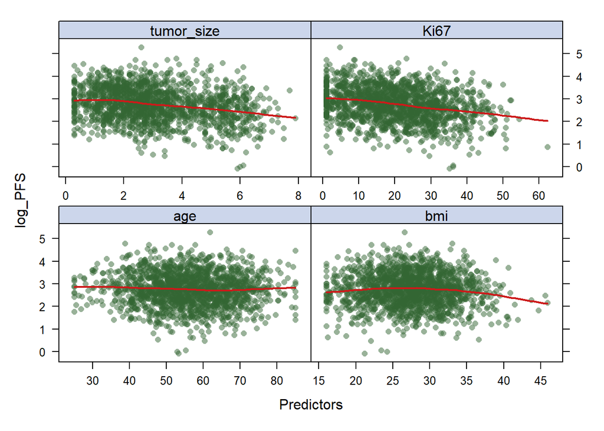

```r
# Feature plots to look at trends between predictors and the outcome (log_PFS)
featurePlot(x = training_datB[ ,c(1, 4, 5, 11)],
            y = training_datB[ ,16],
            plot = "scatter",
            span = .5,
            labels = c("Predictors","log_PFS"),
            type = c("p", "smooth"),
            layout = c(2, 2))
```

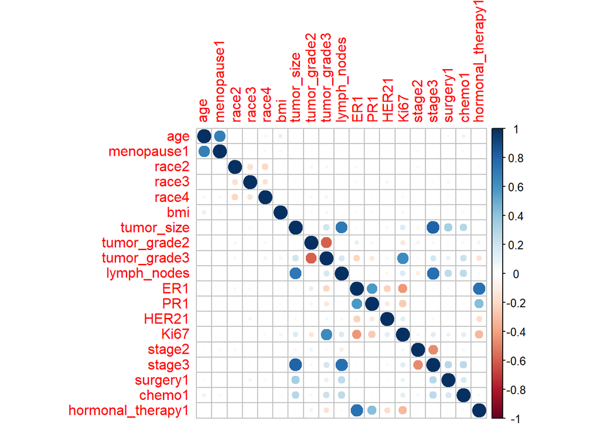

```r
# Calculates the correlation matrix for all the predictors
corrplot(cor(x_trainB), method = "circle", type = "full")
```

## Elastic Net model

```r
# Elastic Net

set.seed(2)
ctrl1 <- trainControl(method = "cv", number = 10) # set up cv
set.seed(2) # set seed for reproduction

enet.test.b <- train(log_PFS ~ .,
                  data = training_datB,
                  method = "glmnet",
                  tuneGrid = expand.grid(alpha = seq(0, 1, length = 21),
                                         lambda = exp(seq(-1, -7, length = 100))),
                  trControl = ctrl1)
enet.test.b$bestTune
```

```
##    alpha    lambda
## 91     0 0.2132149
```

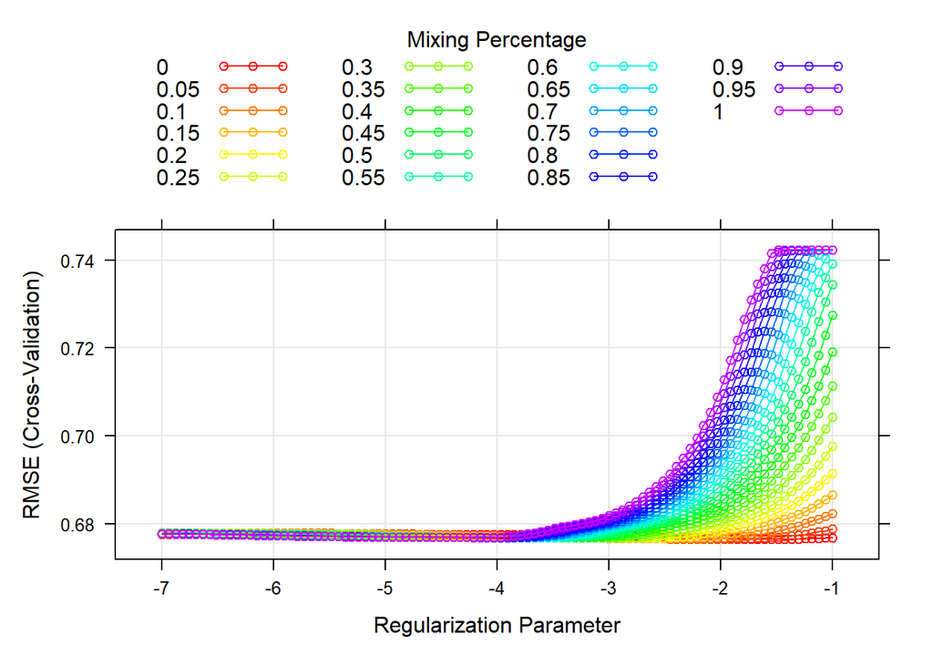

```r
myCol <- rainbow(25)
myPar <- list(superpose.symbol = list(col = myCol),
superpose.line = list(col = myCol))

plot(enet.test.b, par.settings = myPar, xTrans = log)
```

```r
# Coefficients in the final model
coef(enet.test.b$finalModel, enet.test.b$bestTune$lambda)
```

```
## 20 x 1 sparse Matrix of class "dgCMatrix"
##                    s=0.2132149
## (Intercept)        2.998651952
## age               -0.002471616
## menopause1        -0.008133823
## race2             -0.040104815
## race3             -0.024429393
## race4              0.068951230
## bmi               -0.001545360
## tumor_size        -0.042193986
## tumor_grade2       0.074766605
## tumor_grade3      -0.106566952
## lymph_nodes       -0.016611495
## ER1                0.144906908
## PR1                0.096289175
## HER21              0.024744777
## Ki67              -0.004773993
## stage2             0.003120753
## stage3            -0.074148475
## surgery1          -0.025326354
## chemo1            -0.030902468
## hormonal_therapy1  0.165089624
```

```r
# Predict on testing_datB
enet.pred.b <- predict(enet.test.b, newdata = testing_datB)

rmse_testB <- RMSE(enet.pred.b, testing_datB$log_PFS)
r2_testB  <- R2(enet.pred.b, testing_datB$log_PFS)
```

```r
# Create table with the optimal tuning parameters for the chosen model
opt_para <- enet.test.b$bestTune
rownames(opt_para) <- NULL
opt_para |>
  kable()
```

| alpha | lambda |
| --- | --- |
| 0 | 0.2132149 |

```r
# Create a table with the model coefficients
coefs1 <- as.data.frame(as.matrix(coef(enet.test.b$finalModel, enet.test.b$bestTune$lambda)))
coefs1$Predictors <- rownames(coefs1)
colnames(coefs1)[1] <- "Coefficients"
coefs1 <- coefs1[, c("Predictors", "Coefficients")]
rownames(coefs1) <- NULL
coefs1 |>
  kable()
```

| Predictors | Coefficients |
| --- | --- |
| (Intercept) | 2.9986520 |
| age | -0.0024716 |
| menopause1 | -0.0081338 |
| race2 | -0.0401048 |
| race3 | -0.0244294 |
| race4 | 0.0689512 |
| bmi | -0.0015454 |
| tumor_size | -0.0421940 |
| tumor_grade2 | 0.0747666 |
| tumor_grade3 | -0.1065670 |
| lymph_nodes | -0.0166115 |
| ER1 | 0.1449069 |
| PR1 | 0.0962892 |
| HER21 | 0.0247448 |
| Ki67 | -0.0047740 |
| stage2 | 0.0031208 |
| stage3 | -0.0741485 |
| surgery1 | -0.0253264 |
| chemo1 | -0.0309025 |
| hormonal_therapy1 | 0.1650896 |

```r
# Create a table with the exponentiated coefficients
coefs2 <- as.data.frame(as.matrix(coef(enet.test.b$finalModel, enet.test.b$bestTune$lambda)))
coefs2$Predictors <- rownames(coefs2)
colnames(coefs2)[1] <- "Exponentiated Coefficients"
coefs2 <- coefs2[, c("Predictors", "Exponentiated Coefficients")]
coefs2$`Exponentiated Coefficients`<- exp(coefs2$`Exponentiated Coefficients`)
rownames(coefs2) <- NULL
coefs2 |>
  kable()
```

| Predictors | Exponentiated Coefficients |
| --- | --- |
| (Intercept) | 20.0584789 |
| age | 0.9975314 |
| menopause1 | 0.9918992 |
| race2 | 0.9606887 |
| race3 | 0.9758666 |
| race4 | 1.0713840 |
| bmi | 0.9984558 |
| tumor_size | 0.9586838 |
| tumor_grade2 | 1.0776326 |
| tumor_grade3 | 0.8989149 |
| lymph_nodes | 0.9835257 |
| ER1 | 1.1559320 |
| PR1 | 1.1010774 |
| HER21 | 1.0250535 |
| Ki67 | 0.9952374 |
| stage2 | 1.0031256 |
| stage3 | 0.9285338 |
| surgery1 | 0.9749917 |
| chemo1 | 0.9695701 |
| hormonal_therapy1 | 1.1794988 |

```r
# Create table with model performance results
tibble(
  "RMSE" = rmse_testB,
  "R^2" = r2_testB
) |>
  kable()
```

| RMSE | R^2 |
| --- | --- |
| 0.6555808 | 0.1645233 |

## Compare coefficients from datA & datB model

```r
## Compare datA & datB model's exponentiated values

# extract coefficients from both models
coefs_A <- as.data.frame(as.matrix(coef(enet.fit$finalModel,
                                         enet.fit$bestTune$lambda)))
coefs_B <- as.data.frame(as.matrix(coef(enet.test.b$finalModel,
                                         enet.test.b$bestTune$lambda)))

# rename columns
colnames(coefs_A) <- "Coef_datA"
colnames(coefs_B) <- "Coef_datB"

# add predictor names
coefs_A$Predictor <- rownames(coefs_A)
coefs_B$Predictor <- rownames(coefs_B)

# merge both into one table
coef_comparison <- merge(coefs_A, coefs_B, by = "Predictor", all = TRUE)

# exponentiate both and compute difference on exponentiated scale
coef_comparison$Exp_datA   <- round(exp(coef_comparison$Coef_datA), 4)
coef_comparison$Exp_datB   <- round(exp(coef_comparison$Coef_datB), 4)
coef_comparison$Difference <- round(coef_comparison$Exp_datB - coef_comparison$Exp_datA, 4)

# sort by absolute difference
coef_comparison <- coef_comparison[order(abs(coef_comparison$Difference),
                                          decreasing = TRUE), ]
rownames(coef_comparison) <- NULL

# keep only exponentiated columns
coef_comparison <- coef_comparison[, c("Predictor", "Exp_datA", "Exp_datB", "Difference")]

# display table
coef_comparison |>
  kable(caption = "Comparison of Elastic Net Coefficients: datA vs datB",
        col.names = c("Predictor",
                      "datA (Exp. Coefficient)",
                      "datB (Exp. Coefficient)",
                      "Difference"))
```

Comparison of Elastic Net Coefficients: datA vs datB

| Predictor | datA (Exp. Coefficient) | datB (Exp. Coefficient) | Difference |
| --- | --- | --- | --- |
| (Intercept) | 14.2914 | 20.0585 | 5.7671 |
| HER21 | 0.8410 | 1.0251 | 0.1841 |
| PR1 | 1.0000 | 1.1011 | 0.1011 |
| race4 | 0.9758 | 1.0714 | 0.0956 |
| tumor_grade2 | 1.0000 | 1.0776 | 0.0776 |
| stage3 | 1.0000 | 0.9285 | -0.0715 |
| race2 | 1.0000 | 0.9607 | -0.0393 |
| lymph_nodes | 0.9474 | 0.9835 | 0.0361 |
| race3 | 1.0109 | 0.9759 | -0.0350 |
| ER1 | 1.1864 | 1.1559 | -0.0305 |
| chemo1 | 1.0000 | 0.9696 | -0.0304 |
| surgery1 | 0.9990 | 0.9750 | -0.0240 |
| tumor_size | 0.9469 | 0.9587 | 0.0118 |
| menopause1 | 1.0000 | 0.9919 | -0.0081 |
| hormonal_therapy1 | 1.1723 | 1.1795 | 0.0072 |
| stage2 | 1.0000 | 1.0031 | 0.0031 |
| bmi | 1.0000 | 0.9985 | -0.0015 |
| tumor_grade3 | 0.8997 | 0.8989 | -0.0008 |
| Ki67 | 0.9954 | 0.9952 | -0.0002 |
| age | 0.9974 | 0.9975 | 0.0001 |